# Default

## Gradient Boosted Trees

```r
boosted_loan <- boost_tree(mtry = tune(),
                           trees = tune(),
                           learn_rate = tune()) %>%
  set_engine("xgboost") %>%
  set_mode("classification")

boosted_loan_wf <- workflow() %>%
  add_model(boosted_loan) %>%
  add_recipe(loan_recipe)
```

```r
bt_grid <- grid_regular(mtry(range = c(1, 10)),
                        trees(range = c(200, 600)),
                        learn_rate(range = c(-10, -1)),
                        levels = 5)
bt_grid
```

```
## # A tibble: 125 × 3
##     mtry trees   learn_rate
##    <int> <int>        <dbl>
##  1     1   200 0.0000000001
##  2     3   200 0.0000000001
##  3     5   200 0.0000000001
##  4     7   200 0.0000000001
##  5    10   200 0.0000000001
##  6     1   300 0.0000000001
##  7     3   300 0.0000000001
##  8     5   300 0.0000000001
##  9     7   300 0.0000000001
## 10    10   300 0.0000000001
## # ℹ 115 more rows
```

Boosted trees have 3 hyper parameters

mtry, the number of predictors to consider at each split of the tree

trees, the amount of decision trees to be created in the Forrest

learning_rate, the shrinkage parameter lambda determines how much of an effect each individual tree has on the overall model.

```r
tune_bt_loan <- tune_grid(
  boosted_loan_wf,
  resamples = loan_folds,
  grid = bt_grid,
  control = control_grid(verbose = TRUE)
)
```

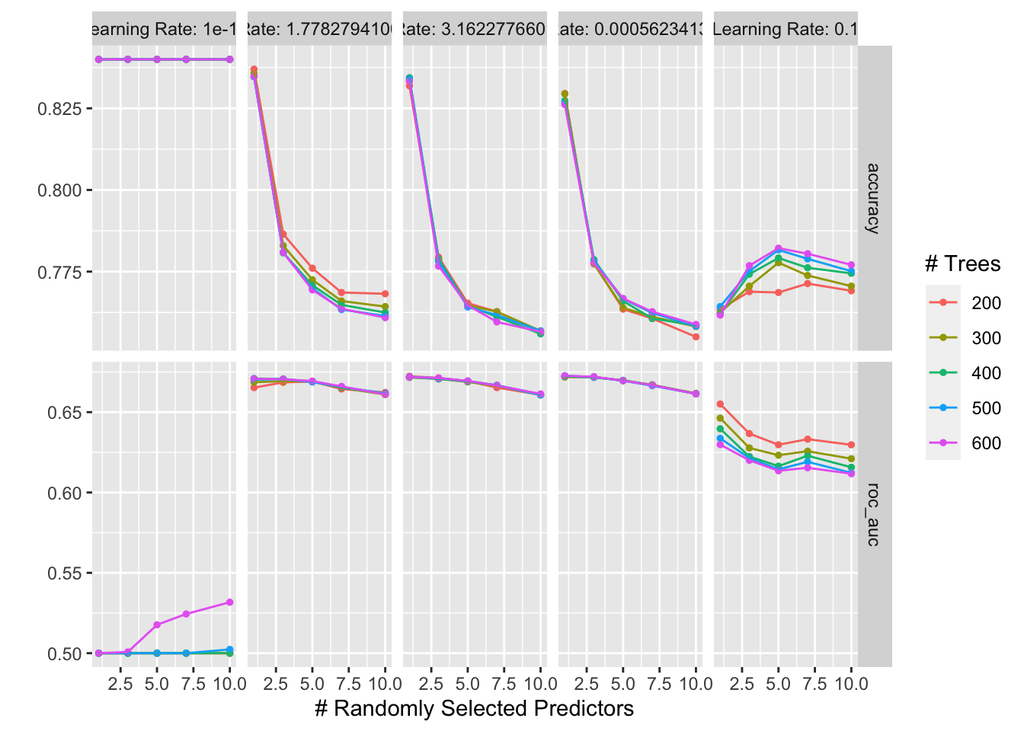

```r
#write_rds(tune_bt_loan, file = "boostT_loan.rds")

tune_bt_loan <- read_rds("boostT_loan.rds")

autoplot(tune_bt_loan)
```

```r
best_boosted <- select_by_one_std_err(tune_bt_loan,
                         metric = "roc_auc",
                         mtry,
                         trees,
                         learn_rate)

best_boosted
```

```
## # A tibble: 1 × 11
##    mtry trees learn_rate .metric .estimator  mean     n std_err .config    .best
##   <int> <int>      <dbl> <chr>   <chr>      <dbl> <int>   <dbl> <chr>      <dbl>
## 1     1   200 0.00000316 roc_auc binary     0.672     5 0.00658 Preproces… 0.673
## # ℹ 1 more variable: .bound <dbl>
```

Which Model had the best ROC_AUC?

```r
Model_fold_roc_auc <- c(best_boosted$mean,
                        best_en$mean,
                        best_knn$mean,
                        best_tree$mean)
models <- c('Boosted Trees', 'Elastic Net', 'KNN', 'Pruned Trees')

results <- tibble(ROC_AUC = Model_fold_roc_auc, models = models)
results %>%
  arrange(-ROC_AUC)
```

```
## # A tibble: 4 × 2
##   ROC_AUC models
##     <dbl> <chr>
## 1   0.673 Elastic Net
## 2   0.673 Pruned Trees
## 3   0.672 Boosted Trees
## 4   0.587 KNN
```

## Finalize Elastic Net

```r
EN_final <- finalize_workflow(elastic_loan_wflow, best_en)

EN_final <- fit(EN_final, data = loan_train)
```

The Elastic net model has now been trained on all the training data.

## Model Performance on Training Set

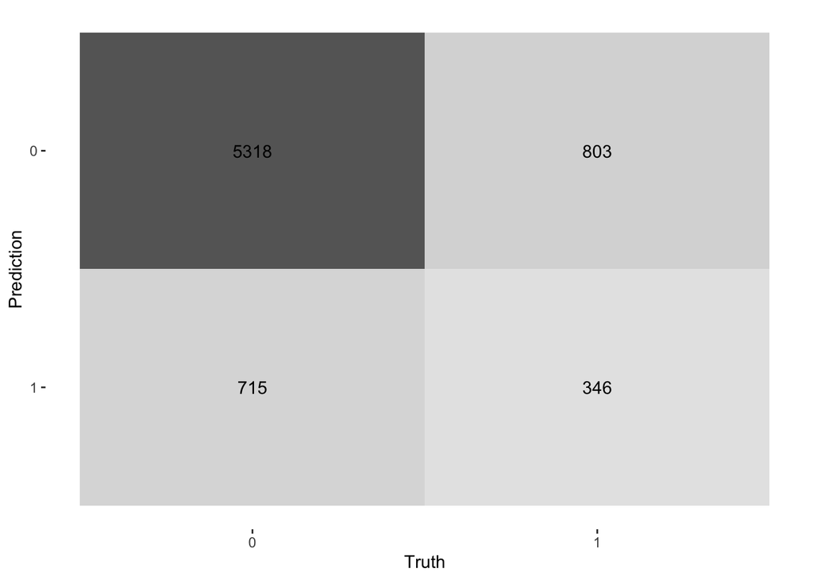

```r
final_en_model_train <- augment(EN_final, new_data = loan_train) %>%
  select(not.fully.paid, starts_with('.pred'))

conf_mat(final_en_model_train, truth = not.fully.paid,
         .pred_class) %>%
  autoplot(type = "heatmap")
```

Threshold on training

```r
threshold <- 0.38  # Adjust the threshold as needed

# Create a new column with adjusted predictions based on the threshold
df <- final_en_model_train %>%
  mutate(adjusted_prediction = ifelse(.pred_1 >= threshold, "1", "0"))

df
```

```
## # A tibble: 7,182 × 5
##    not.fully.paid .pred_class .pred_0 .pred_1 adjusted_prediction
##    <fct>          <fct>         <dbl>   <dbl> <chr>
##  1 0              0             0.773   0.227 0
##  2 0              0             0.578   0.422 1
##  3 0              0             0.752   0.248 0
##  4 0              0             0.786   0.214 0
##  5 0              0             0.872   0.128 0
##  6 0              0             0.686   0.314 0
##  7 0              0             0.712   0.288 0
##  8 0              0             0.837   0.163 0
##  9 0              0             0.676   0.324 0
## 10 0              0             0.738   0.262 0
## # ℹ 7,172 more rows
```

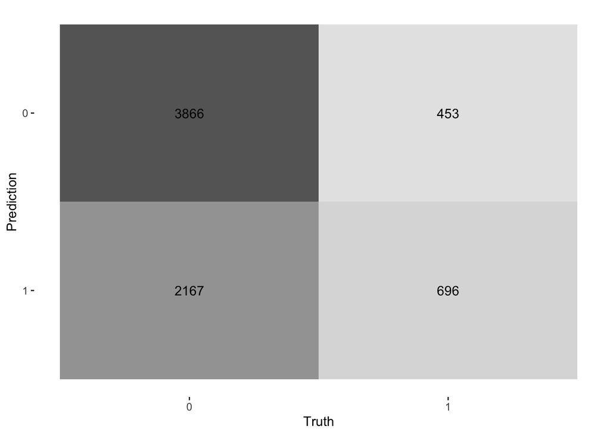

```r
df$adjusted_prediction <- factor(df$adjusted_prediction, levels = levels(df$not.fully.paid))


conf_mat(df, truth = not.fully.paid,
         adjusted_prediction) %>%
  autoplot(type = "heatmap")
```